# Introduction to BLiSS method

Paul-Marie Grollemund

2020-07-07

```r
  library(bliss)
```

This vignette describes step by step how to use the BLiSS method, by:

- simulate data to illustrate the BLiSS model
- obtain a sample of the *a posteriori* distribution with a sampler of Gibbs
- plot the *a posteriori* distribution of the coefficient function and that of its support
- calculate the different Bayesian estimators and plot the results in a graph

# 1 One single functional covariate

## 1.1 Simulation of the data set

To obtain data, several characteristics must be specified to simulate the data, such as n (number of observations), p (number of measurement moments) curves $x_{i}(.)$), beta$\_$types (the shape of the coefficient function), and b$\_$inf and b$\_$sup (to define the domain of curves $x_{i}(.)$). Based on these parameters, we can use the *sim* function in the following code to simulate $x_{i}(.)$ curves, and real values $y_{i}$, from the functional linear regression model.

```r
  param <- list(                        # define the "param" to simulate data
                Q=1,                    # the number of functional covariate
                n=100,                  # n is the sample size and p is the
                p=c(50),                # number of time observations of the curves
                beta_types=c("smooth"), # define the shape of the "true" coefficient function
                grids_lim=list(c(0,1))) # Give the beginning and the end of the observation's domain of the functions.

  data <- sim(param) # Simulate the data
```

## 1.2 Apply the Bliss method

To obtain an *a posteriori* sample, we use the Gibbs algorithm. We use the main function *fit$\_$Bliss* which calls sub-functions that allow us

- to sample the *a posteriori* distribution,
- then to calculate the *a posteriori* distribution of the coefficient function,
- to execute an optimization algorithm to calculate a constant estimate by pieces,
- to calculate an estimation of the support and to calculate the density of the sample a posteriori (useful to calculate the BIC criterion).

This main function requires a **param** list containing

- **iter**, the number of iterations of the Gibbs algorithm,
- **burnin** heating time,
- **K**, hyperparameter K of the Bliss model,
- **grids**, the moments of measurement of the curves $x_{i}(.)$,
- **prior$\_$beta**, an argument specifying the distribution a priori of $\beta$ **Ridge$\_$Zellner** is only considered in this vignette
- and **phi$\_$l**, an argument specifying the *a priori* distribution of (only the **Gamma** option is considered in this vignette).

```r
  param <- list(            # define the required values of the Bliss method.
                iter=1e3,   # The number of iteration of the main numerical algorithm of Bliss.
                burnin=2e2, # The number of burnin iteration for the Gibbs Sampler
                K=c(3))     # The number of intervals of the beta


  res_bliss<-fit_Bliss(data=data,param=param,verbose=TRUE)
```

```
#> Sample from the posterior distribution.
#> Gibbs Sampler:
#>   Initialization.
#>   Determine the starting point.
#>   Start the Gibbs Sampler.
#>   10%
#>   20%
#>   30%
#>   40%
#>   50%
#>   60%
#>   70%
#>   80%
#>   90%
#>   100%
#>   Return the result.
#> Coefficient function: smooth estimate.
#> Coefficient function: Bliss estimate.
#> Compute the approximation of the posterior distribution.
#> Support estimation.
#> Compute the (log) densities of the posterior sample.
```

```r
  # Structure of a Bliss object
  str(res_bliss)
```

```
#> List of 12
#>  $ alpha                 :List of 1
#>   ..$ : num [1:50] 0.148 0.182 0.288 0.591 0.845 ...
#>  $ beta_posterior_density:List of 1
#>   ..$ :List of 4
#>   .. ..$ grid_t         : num [1:512] 0 0.00196 0.00391 0.00587 0.00783 ...
#>   .. ..$ grid_beta_t    : num [1:512] -6.17 -6.15 -6.13 -6.11 -6.09 ...
#>   .. ..$ density        : num [1:512, 1:512] 2.03e-22 3.29e-22 5.30e-22 8.54e-22 1.37e-21 ...
#>   .. ..$ new_beta_sample: num [1:800, 1:50] 0 0 0 0 0 0 0 0 0 0 ...
#>  $ beta_sample           :List of 1
#>   ..$ : num [1:1001, 1:50] 0 0 -3.41 1.88 3.27 ...
#>  $ Bliss_estimate        :List of 1
#>   ..$ : num [1:50, 1] 0 0 0 2.57 2.57 ...
#>  $ chains                : NULL
#>  $ chains_info           :List of 1
#>   ..$ :List of 2
#>   .. ..$ estimates   :List of 3
#>   .. .. ..$ mu_hat         : num 1.04
#>   .. .. ..$ sigma_sq_hat   : num 0.302
#>   .. .. ..$ Smooth_estimate: num [1:50] 0.325 0.405 0.696 1.593 2.428 ...
#>   .. ..$ autocorr_lag: num [1:50, 1:3] -0.2915 -0.1568 -0.1449 -0.0898 -0.0187 ...
#>   .. .. ..- attr(*, "dimnames")=List of 2
#>   .. .. .. ..$ : NULL
#>   .. .. .. ..$ : chr [1:3] "mu" "sigma_sq" "beta"
#>  $ data                  :List of 6
#>   ..$ Q     : num 1
#>   ..$ y     : num [1:100] 0.924 1.837 0.91 1.684 -0.96 ...
#>   ..$ x     :List of 1
#>   .. ..$ : num [1:100, 1:50] -0.204 -0.538 0.62 -0.298 -0.142 ...
#>   .. .. ..- attr(*, "scaled:center")= num [1:50] 0.905 0.821 0.738 0.668 0.6 ...
#>   ..$ betas :List of 1
#>   .. ..$ : num [1:50] 0 0 0 0 3 3 3 3 3 3 ...
#>   ..$ grids :List of 1
#>   .. ..$ : num [1:50] 0 0.0204 0.0408 0.0612 0.0816 ...
#>   ..$ x_save:List of 1
#>   .. ..$ : num [1:100, 1:50] 0.701 0.367 1.526 0.607 0.764 ...
#>  $ posterior_sample      :List of 3
#>   ..$ trace            : num [1:1001, 1:11] -0.271 1.414 1.655 0.503 1.024 ...
#>   .. ..- attr(*, "dimnames")=List of 2
#>   .. .. ..$ : NULL
```

[output cut: 15 more lines]

```
#>   .. .. ..$ : chr [1:6] "posterior density" "log posterior density" "likelihood" "log likelihood" ...
#>  $ Smooth_estimate       :List of 1
#>   ..$ : num [1:50, 1] 0.325 0.405 0.696 1.593 2.428 ...
#>  $ support_estimate      :List of 1
#>   ..$ :'data.frame': 3 obs. of  2 variables:
#>   .. ..$ begin: num [1:3] 4 25 42
#>   .. ..$ end  : num [1:3] 16 30 46
#>  $ support_estimate_fct  :List of 1
#>   ..$ : num [1:50] 0 0 0 1 1 1 1 1 1 1 ...
#>  $ trace_sann            :List of 1
#>   ..$ : num [1:50001, 1:16] 0.532 0.532 0.532 0.532 0.532 ...
#>   .. ..- attr(*, "dimnames")=List of 2
#>   .. .. ..$ : NULL
#>   .. .. ..$ : chr [1:16] "b_1" "b_2" "b_3" "b_4" ...
#>  - attr(*, "class")= chr "bliss"
```

## 1.3 Plot the result

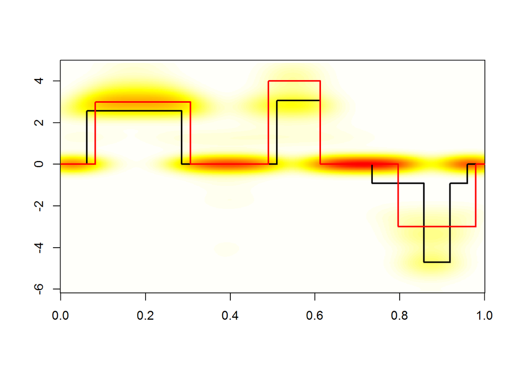

```r
  param$ylim <- range(range(res_bliss$beta_posterior_density[[1]]$grid_beta_t),
                      c(-5,5))
  param$cols <- rev(heat.colors(100))
  image_Bliss(res_bliss$beta_posterior_density,param,q=1)
  lines(res_bliss$data$grids[[1]],res_bliss$Bliss_estimate[[1]],type="s",lwd=2)
  lines(res_bliss$data$grids[[1]],res_bliss$data$betas[[1]],col=2,lwd=2,type="s")
```

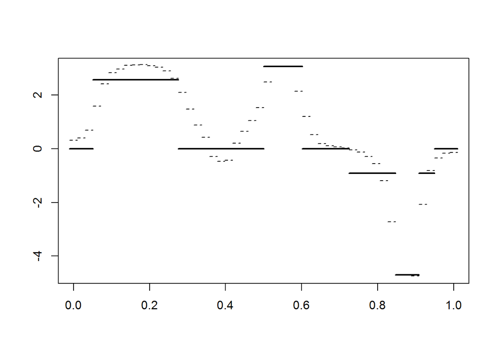

```r
  ylim <- range(range(res_bliss$Bliss_estimate[[1]]),
                range(res_bliss$Smooth_estimate[[1]]))
  plot_bliss(res_bliss$data$grids[[1]],
             res_bliss$Bliss_estimate[[1]],lwd=2)
  lines_bliss(res_bliss$data$grids[[1]],
             res_bliss$Smooth_estimate[[1]],lty=2)
```

# 2 Several functional covariates

To avoid execution lengths, this section is not executed. Please, give it a try.

## 2.1 Simulate the dataset

```r
   param <- list(Q=2,
                 n=300,
                 p=c(40,60),
                 beta_shapes=c("simple","smooth"),
                 grids_lim=list(c(0,1),c(0,2)))

  data <- sim(param)
```

## 2.2 Apply the Bliss method

```r
  param <- list(       # define the required values of the Bliss method.
     iter=1e3,         # The number of iteration of the main numerical algorithm of Bliss.
     burnin=2e2,       # The number of burnin iteration for the Gibbs Sampler
     K=c(3,3))         # The number of intervals of the beta

  res_Bliss_mult <- fit_Bliss(data=data,param=param)
```

## 2.3 Plot the result

```r
   q <- 1
   param$ylim <- range(range(res_Bliss_mult$beta_posterior_density[[q]]$grid_beta_t),
                       c(-5,5))
   param$cols <- rev(heat.colors(100))
   image_Bliss(res_Bliss_mult$beta_posterior_density,param,q=q)
   lines(res_Bliss_mult$data$grids[[q]],res_Bliss_mult$Bliss_estimate[[q]],type="s",lwd=2)
   lines(res_Bliss_mult$data$grids[[q]],res_Bliss_mult$data$betas[[q]],col=2,lwd=2,type="s")

  ylim <- range(range(res_Bliss_mult$Bliss_estimate[[q]]),
                 range(res_Bliss_mult$Smooth_estimate[[q]]))
   plot_bliss(res_Bliss_mult$data$grids[[q]],
              res_Bliss_mult$Bliss_estimate[[q]],lwd=2,ylim=ylim)
   lines(res_Bliss_mult$data$grids[[q]],
         res_Bliss_mult$Smooth_estimate[[q]],lty=2)


   q <- 2
   param$ylim <- range(range(res_Bliss_mult$beta_posterior_density[[q]]$grid_beta_t),
                       c(-5,5))
   param$cols <- rev(heat.colors(100))
   image_Bliss(res_Bliss_mult$beta_posterior_density,param,q=q)
   lines(res_Bliss_mult$data$grids[[q]],res_Bliss_mult$Bliss_estimate[[q]],type="s",lwd=2)
   lines(res_Bliss_mult$data$grids[[q]],res_Bliss_mult$data$betas[[q]],col=2,lwd=2,type="l")

   ylim <- range(range(res_Bliss_mult$Bliss_estimate[[q]]),
                 range(res_Bliss_mult$Smooth_estimate[[q]]))
   plot_bliss(res_Bliss_mult$data$grids[[q]],
              res_Bliss_mult$Bliss_estimate[[q]],lwd=2,ylim=ylim)
   lines(res_Bliss_mult$data$grids[[q]],
         res_Bliss_mult$Smooth_estimate[[q]],lty=2)
```